# Listas

Uma lista é uma estrutura de dados composta por itens organizados de forma linear, na qual cada um pode ser acessado a partir de um índice, que representa sua posição na coleção (iniciando em zero).

Em Python, esta estrutura de dados pode armazenar objetos de diferentes tipos (strings, números, outras listas e dicionários).

### Criando listas

Em Python, uma lista é representada como uma sequência de objetos separados por vírgula e dentro de colchetes [], assim, uma lista vazia, por exemplo, pode ser representada por colchetes sem nenhum conteúdo. A seguir, mostraremos algumas possibilidades de criação desse tipo de objeto.

```python
lista1 = []
lista2 = ['cachorro', 'gato', 'papagaio',1,2,3]
lista3 = list()
lista4 = list((1,2,3,4,5,6))
print(lista1)
print(lista2)
print(lista3)
print(lista4)
```

```
[]
['cachorro', 'gato', 'papagaio', 1, 2, 3]
[]
[1, 2, 3, 4, 5, 6]
```

Como podemos ver, podemos declarar uma lista a partir de colchetes ou a partir do comando list().

A linguagem Python dispõe de vários métodos e operadores para auxiliar na manipulação de listas. O primeiro e mais básico é o operador de acesso aos seus itens a partir dos índices. Para compreendê-lo, é importante entender como os dados são armazenados nessa estrutura, o que é ilustrado na figura a seguir.

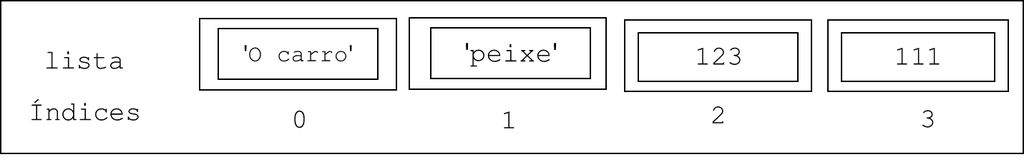

A lista representada nessa figura é composta por quatro elementos, cujos índices variam de zero a três. Por exemplo, o primeiro objeto, no índice 0, é a string 'O carro'. Tendo em mente essa organização interna, podemos acessar cada um dos elementos utilizando a sintaxe lista[índice], como mostraremos a seguir:

```python
lista = ['O carro','peixe',123,111]
print(lista[0])
print(lista[2])
print(lista[3])
```

```
O carro
123
111
```

Agora, no caso da lista abaixo:

```
                            lista = [[1,2,3],[4,5,6]]
```

Como faríamos para acessar o número 2? Se tentarmos algo análogo ao que fizemos no exemplo anterior, teremos o seguinte:

```python
lista = [[1,2,3],[4,5,6]]
print(lista[1])
```

```
[4, 5, 6]
```

Isso acontece porque agora temos uma lista com mais de uma dimensão (no caso, temos 2 dimensões). Podemos vulgarmente falar que temos listas dentro de uma lista. Então, o componente de índice 1 da lista 'lista' é a lista [4,5,6]. Para acessarmos os componentes da lista de dentro, precisamos declarar o índice referente a lista que o componente se encontra e, em seguida, o índice em que o próprio componente se encontra. Dessa forma:

```python
print(lista[0][1])
```

```
2
```

Agora temos o que queríamos. A lista que contém o número 2 ocupa o índice 0 da lista "de fora" e o número 2 ocupa o índice 1 de sua lista. Por isso usamos 'lista[0][1]'.

### Comprimento de uma lista

O comprimento de uma lista, ou o número de itens que a compõem, pode ser obtido a partir da função len(), como mostra o código abaixo:

```python
lista = [0,1,2,3,4,5,6,7,8,9,10]
comprimento = len(lista)
print(comprimento)
```

```
11
```

### Concatenação e multiplicação de listas

Também é possível concatenar listas por meio do operador de adição + e multiplicá-las por um inteiro, o que gerará várias cópias dos seus itens. O código a seguir traz alguns exemplos dessas operações:

```python
lista = ['O carro','peixe',123,111]
lista2 =['A moto', 'gato', 321, 222]
soma = lista + lista2
print(soma)
```

```
['O carro', 'peixe', 123, 111, 'A moto', 'gato', 321, 222]
```

```python
multiplicação = lista*3
print(multiplicação)
```

```
['O carro', 'peixe', 123, 111, 'O carro', 'peixe', 123, 111, 'O carro', 'peixe', 123, 111]
```

### Verificação da existência de itens em uma lista

Em alguns casos é preciso verificar se um determinado valor está contido em uma lista. Para isso, em Python utilizamos o operador in, que indicará True se objeto pertencer ao conjunto, e False caso contrário. No código a seguir temos exemplos de uso desse operador:

```python
'peixe' in lista
```

```
True
```

```python
'gato' in lista
```

```
False
```

### Máximos, mínimos e soma

As funções max(), min() e sum() retornam, respectivamente, o valor máximo, mínimo e a soma dos valores de uma lista. Veja:

```python
números = [0,1,2,3,4,5]
max(números)
min(números)
sum(números)
```

```
15
```

### Métodos

#### Append

Adiciona um novo elemento ao final de uma lista já existente

```python
lista = [0,2,4,6,8,10]
lista.append(12)
print(lista)
```

```
[0, 2, 4, 6, 8, 10, 12]
```

#### Insert

Insere um novo elemento em uma lista já existente, determinando sua posição

```python
lista = [0,2,6]
lista.insert(2,4)
print(lista)
```

```
[0, 2, 4, 6]
```

Neste caso, inserimos o número 4 no índice 2, que antes era ocupado pelo número 6. Com a inserção, o número 6 passou a ocupar o índice 3.

#### Pop

Remove o último elemento de uma lista e o retorna como resultado da operação. Caso queira excluir um outro elemento que não o último, é preciso passar seu índice como parâmetro

```python
lista = ['a','b','c','d']
lista.pop()
```

```
'd'
```

```python
lista.pop(0)
```

```
'a'
```

#### Remove

Quando queremos excluir um elemento da lista, mas não sabemos sua posição, usamos o método remove.

```python
lista = ['Java','Html','Python','Fortran']
lista.remove('Fortran')
print(lista)
```

```
['Java', 'Html', 'Python']
```

#### Sort

O comando sort é utilizado para ordenar em ordem crescente os valores de uma lista (ordem lexicográfica para strings).

```python
lista = ['e','a','b','d','c']
lista.sort()
print(lista)
```

```
['a', 'b', 'c', 'd', 'e']
```

```python
lista = [5,2,6,1,8,3,5,6]
lista.sort()
print(lista)
```

```
[1, 2, 3, 5, 5, 6, 6, 8]
```

#### Reverse

Inverte a ordem dos elementos de uma lista

```python
lista = [0,2,1,5,2]
lista.reverse()
print(lista)
```

```
[2, 5, 1, 2, 0]
```

#### Count

Retorna o número de ocorrências de um elemento numa lista

```python
lista = [0,0,0,0,0,0,0,0,0,2,2,2,2,2,2,2,4,4,4,4,4,1,1,4,2,5,1,6,2,]
lista.count(0)
```

```
9
```